# Tourism in India Project Report

Group 16:- Chandan Kumar Singh (231080030), Omkar Yadav (231080062), Soumen Konai (231080091), Ashwani Kumar (231080025), Instructor:- Prof. Dootika Vats

# Introduction

This report provides a detailed explanation of the “Tourism in India” Shiny app. The app is designed to display tourism-related data and visualizations for various parts of India, motorcycle tours, and travel information by month.

India is a land of diverse cultures, landscapes, and traditions which offers a captivating tapestry for tourists. Our project, “Exploring India’s Hidden Gems,” seeks to showcase the uncharted beauty and rich heritage of this incredible country. With a focus on sustainable and responsible tourism, we aim to promote lesser-known destinations, unique cultural experiences, and eco-friendly practices. Through this project, we aspire to foster economic growth in local communities, preserve India’s natural wonders, and provide travelers with unforgettable journeys that go beyond the usual tourist trail. Join us on a transformative voyage through the heart of India and discover its untold stories.

# Objective

This project aims to provide users with an immersive experience by offering a curated selection of the top ten most favorable places in each selected area.

Our Shiny app, ‘Discover India’s Treasures,’ is a user-friendly platform designed to help travelers and enthusiasts explore the breathtaking beauty and cultural richness of India’s diverse states and main regions.

# Data Extraction and Preprocessing

We are extracting data from “https://en.wikipedia.org/wiki/Tourism_in_India”.

Basically we collect the pictures name and the picture url.

We extracted tables as follows:-

table_1 for Foreign tourist arrivals in India (1997–20222).

table_2 for Foreign exchange earnings from tourism in India (1997–2020).

table_3 for Source countries for foreign tourist arrivals in India in 2019.

table_4 for Share of top 10 states/UT’s of India in number of foreign tourist visits in 2017.

table_5 for Share of top 10 states/UT’s of India in number of domestic tourist visits in 2017.

The app fetches data from web sources, primarily Wikipedia. It retrieves tables and images related to tourism in India.

we also try to scrap the places description and put this as a link in shiny app.

final_table for scrapped_final_table .

## Data Visualization and Analysis

The app uses a combination of ggplot2 and DT for data visualization and analysis. Each of the following sections corresponds to a specific tab within the app.

# Foreign Tourist Arrivals in India (1997 – 2022)

| Year | Arrivals (millions) | % change |
| --- | --- | --- |
| 1997 | 2.37 | 3.8 |
| 1998 | 2.36 | −0.7 |
| 1999 | 2.48 | 5.2 |
| 2000 | 2.65 | 6.7 |
| 2001 | 2.54 | −4.2 |
| 2002 | 2.38 | −6.0 |
| 2003 | 2.73 | 14.3 |
| 2004 | 3.46 | 26.8 |
| 2005 | 3.92 | 13.3 |
| 2006 | 4.45 | 13.5 |

[output cut: 16 more lines]

## Data Visualization

The “Foreign tourist arrivals in India (1997–2022)” tab presents a line plot showing the trend in foreign tourist arrivals over the years.

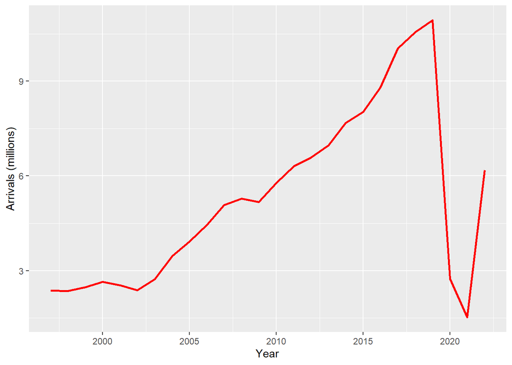

## Insights

On an average the number of people Arrived (millions) (1997 - 2022)

```
## [1] 5.269231
```

# Foreign exchange earnings from tourism in India (1997–2020)

| Year | Earnings (US$ million) | % change | Earnings (₹ crores) | % change |
| --- | --- | --- | --- | --- |
| 1997 | 2,889 | 2.0 | 10,511 | 4.6 |
| 1998 | 2,948 | 2.0 | 12,150 | 15.6 |
| 1999 | 3,009 | 2.1 | 12,951 | 6.6 |
| 2000 | 3,460 | 15 | 15,626 | 20.7 |
| 2001 | 3,198 | −7.6 | 15,083 | −3.5 |
| 2002 | 3,103 | −3.0 | 15,064 | −0.1 |
| 2003 | 4,463 | 43.8 | 20,729 | 37.6 |
| 2004 | 6,170 | 38.2 | 27,944 | 34.8 |
| 2005 | 7,493 | 21.4 | 33,123 | 18.5 |
| 2006 | 8,634 | 15.2 | 39,025 | 17.8 |

[output cut: 14 more lines]

## Data Visualization

The “Foreign exchange earnings from tourism in India (1997–2020)” tab displays a bar chart showing earnings in Indian Rupees over the years.

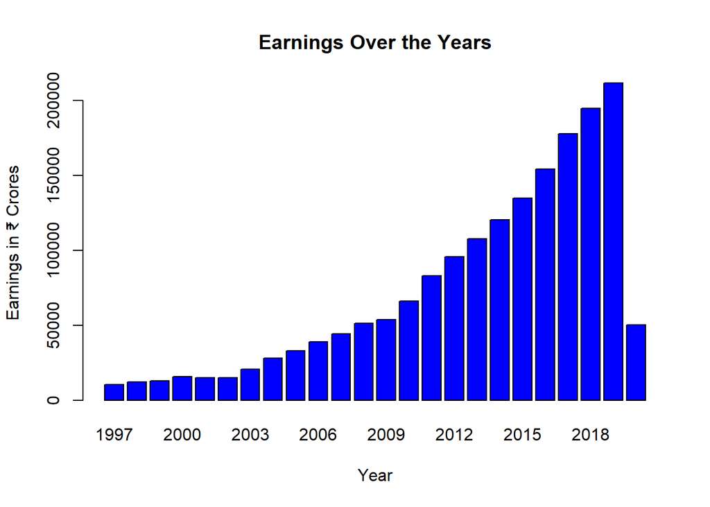

# Source countries for foreign tourist arrivals in India in 2019.

| Rank | Country | Number | Share in % |
| --- | --- | --- | --- |
| 1 | Bangladesh | 2,577,727 | 23.58 |
| 2 | European Union | 2,430,002 | 21.12 |
| 3 | United States | 1,512,032 | 13.83 |
| 4 | United Kingdom | 1,000,292 | 9.15 |
| 5 | Sri Lanka | 380,121 | 3.38 |
| 6 | Australia | 367,241 | 3.36 |
| 7 | Canada | 351,859 | 3.22 |
| 8 | China (mainland) | 339,442 | 3.11 |
| 9 | Malaysia | 334,579 | 3.06 |
| 10 | Germany | 264,973 | 2.42 |

[output cut: 2 more lines]

## Data Visualization

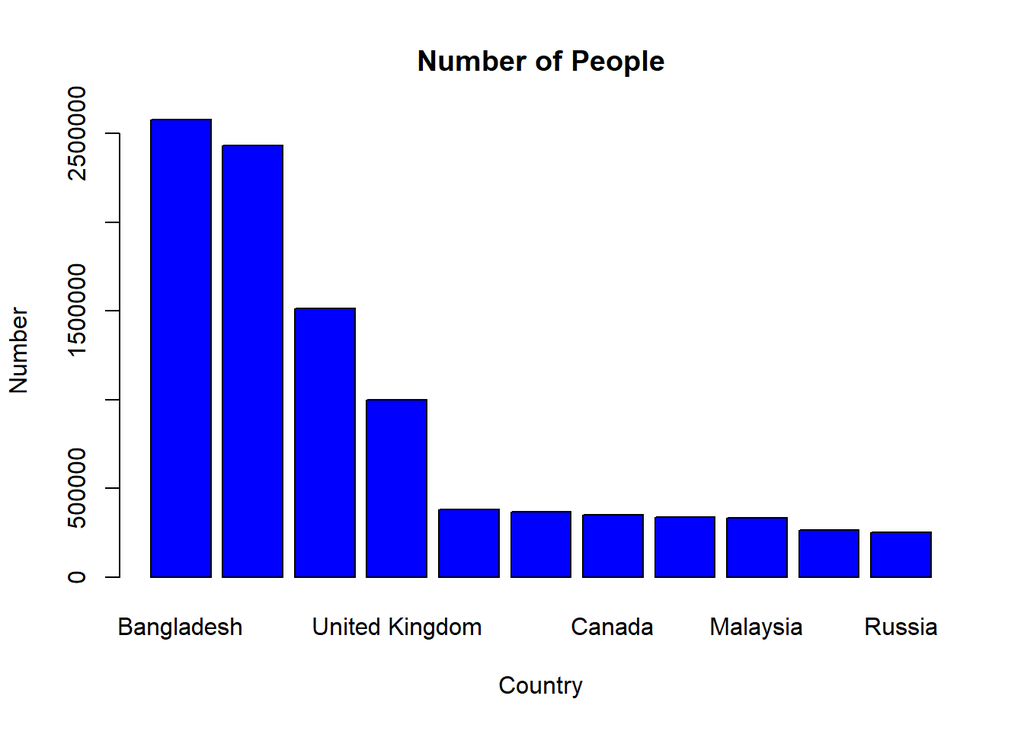

## Insights

Bangladesh is the topmost country with 23.58 % share.

# Share of top 10 states/UTs of India in number of foreign tourist visits in 2017.

| Rank | State/Union Territory | Number | Share in % |
| --- | --- | --- | --- |
| 1 | Maharashtra | 5,078,514 | 18.9 |
| 2 | Tamil Nadu | 4,860,455 | 18.1 |
| 3 | Uttar Pradesh | 3,104,062 | 13.3 |
| 4 | Delhi | 2,379,169 | 10.2 |
| 5 | Rajasthan | 1,489,500 | 6.4 |
| 6 | West Bengal | 1,475,311 | 6.3 |
| 7 | Kerala | 977,479 | 4.2 |
| 8 | Bihar | 923,737 | 4.0 |
| 9 | Karnataka | 636,502 | 2.7 |
| 10 | Goa | 541,480 | 2.3 |

[output cut: 3 more lines]

## Data Visualization

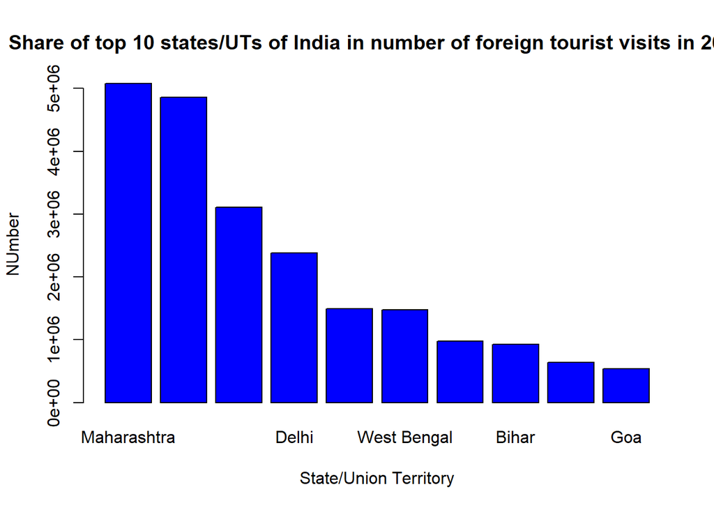

## Insights

Maharashtra of India is the topmost in number of foreign tourist visits with 18.9 %.

# Share of top 10 states/UTs of India in number of domestic tourist visits in 2017.

| Rank | State/Union Territory | Number | Share in % |
| --- | --- | --- | --- |
| 1 | Tamil Nadu | 345,061,140 | 20.9 |
| 2 | Uttar Pradesh | 233,977,619 | 14.2 |
| 3 | Karnataka | 179,980,191 | 10.9 |
| 4 | Andhra Pradesh | 165,433,898 | 10.0 |
| 5 | Maharashtra | 119,191,539 | 7.2 |
| 6 | Telangana | 85,266,596 | 5.2 |
| 7 | Madhya Pradesh | 78,038,522 | 4.7 |
| 8 | West Bengal | 79,687,645 | 4.8 |
| 9 | Gujarat | 48,343,121 | 2.9 |
| 10 | Rajasthan | 45,916,573 | 2.8 |

[output cut: 3 more lines]

## Data Visualization

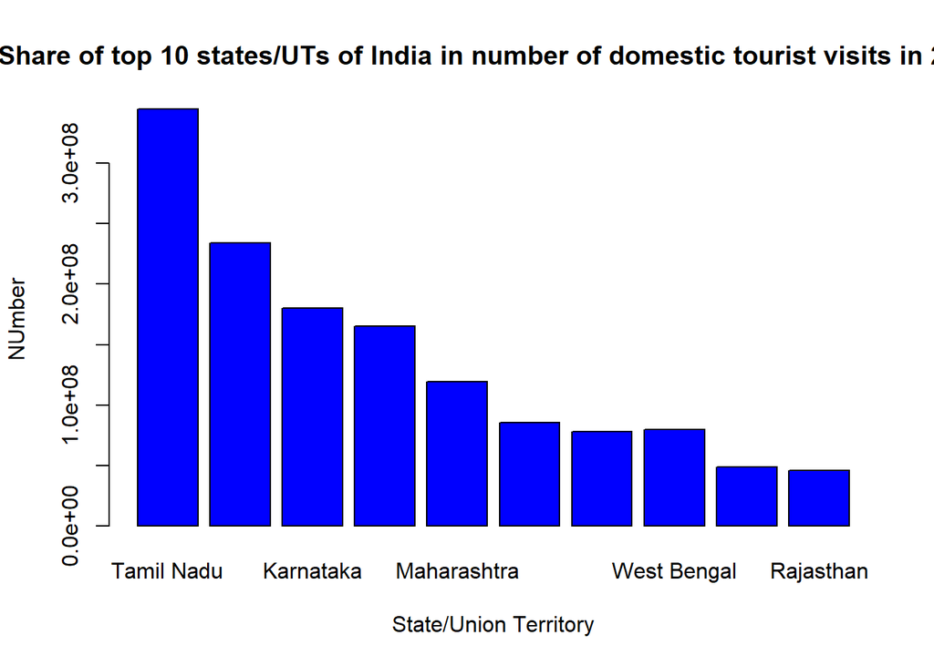

## Insights

Tamil Nadu of India is the topmost in number of domestic tourist visits with 20.9 %.

# Final Table

| Place_to_Visit | discription_link |
| --- | --- |
| Dal Lake in Srinagar | Details |
| Sultanpur National Park in Gurgaon | Details |
| Munshi Ghat in Varanasi | Details |
| Bhangarh Fort, a very popular fort city in Alwar | Details |
| Udaipur's City Palace | Details |
| Boats on Naini Lake in Nainital city | Details |
| Lotus Temple in Delhi | Details |
| Pangong Tso lake in Ladakh | Details |
| Tso Moriri in Ladakh | Details |
| Golden Temple, Amritsar | Details |

[output cut: 72 more lines]

# Main Parts of India

The “Main Parts of India” tab provides users with data related to different parts of India, including North, South, Central, West, East, and Northeast India. Users can select a specific region and view associated data.

## North India

| Data_Type | Picture_URL | url_place_description[1:19] |
| --- | --- | --- |
| Dal Lake in Srinagar | https://upload.wikimedia.org/wikipedia/commons/thumb/e/e1/Dal_Lake_Hazratbal_Srinagar.jpg/120px-Dal_Lake_Hazratbal_Srinagar.jpg | https://en.wikipedia.org//wiki/Dal_Lake |
| Sultanpur National Park in Gurgaon | https://upload.wikimedia.org/wikipedia/commons/thumb/3/35/Sultanpur_Bird_Sanctuary%2C_Haryana..JPG/120px-Sultanpur_Bird_Sanctuary%2C_Haryana..JPG | https://en.wikipedia.org//wiki/Sultanpur_National_Park |
| Munshi Ghat in Varanasi | https://upload.wikimedia.org/wikipedia/commons/thumb/f/fa/Munshi_Ghat_in_Varanasi.jpg/120px-Munshi_Ghat_in_Varanasi.jpg | https://en.wikipedia.org//wiki/Munshi_Ghat |
| Bhangarh Fort, a very popular fort city in Alwar | https://upload.wikimedia.org/wikipedia/commons/thumb/d/da/Bhangarh_Fort_alwar.jpg/120px-Bhangarh_Fort_alwar.jpg | https://en.wikipedia.org//wiki/Bhangarh_Fort |
| Udaipur's City Palace | https://upload.wikimedia.org/wikipedia/commons/thumb/4/4b/Udaipur_City_Palace_November_2013.jpg/120px-Udaipur_City_Palace_November_2013.jpg | https://en.wikipedia.org//wiki/City_Palace,_Udaipur |
| Boats on Naini Lake in Nainital city | https://upload.wikimedia.org/wikipedia/commons/thumb/3/36/A_view_of_Nainital_lake_with_the_morning_mist.jpg/120px-A_view_of_Nainital_lake_with_the_morning_mist.jpg | https://en.wikipedia.org//wiki/Nainital_Lake |
| Lotus Temple in Delhi | https://upload.wikimedia.org/wikipedia/commons/thumb/d/dc/Lotus_Temple_in_New_Delhi_03-2016.jpg/120px-Lotus_Temple_in_New_Delhi_03-2016.jpg | https://en.wikipedia.org//wiki/Lotus_Temple |
| Pangong Tso lake in Ladakh | https://upload.wikimedia.org/wikipedia/commons/thumb/8/83/Pangong_lake_-_Ladakh.jpg/120px-Pangong_lake_-_Ladakh.jpg | https://en.wikipedia.org//wiki/Pangong_Tso |
| Tso Moriri in Ladakh | https://upload.wikimedia.org/wikipedia/commons/thumb/6/65/Karakoram-West_Tibetan_Plateau_alpine_steppe.jpg/120px-Karakoram-West_Tibetan_Plateau_alpine_steppe.jpg | https://en.wikipedia.org//wiki/Tso_Moriri |
| Golden Temple, Amritsar | https://upload.wikimedia.org/wikipedia/commons/thumb/4/4d/Hamandir_Sahib_%28Golden_Temple%29.jpg/120px-Hamandir_Sahib_%28Golden_Temple%29.jpg | https://en.wikipedia.org//wiki/Golden_Temple |

[output cut: 9 more lines]

## South India

| Data_Type | Picture_URL | url_place_description[20:34] |
| --- | --- | --- |
| Tirupati temple | https://upload.wikimedia.org/wikipedia/commons/thumb/4/4e/Tirumala_090615.jpg/120px-Tirumala_090615.jpg | https://en.wikipedia.org//wiki/Venkateswara_Temple,_Tirumala |
| Madikeri or Coorg in Kodagu,Karnataka | https://upload.wikimedia.org/wikipedia/commons/thumb/4/4d/Coorg_-_The_Scotland_of_India.jpg/120px-Coorg_-_The_Scotland_of_India.jpg | https://en.wikipedia.org//wiki/Madikeri |
| Gandikota river valley in Andhra Pradesh | https://upload.wikimedia.org/wikipedia/commons/thumb/a/ad/Grand_Canon_of_India_%28Gandikota%29.jpg/120px-Grand_Canon_of_India_%28Gandikota%29.jpg | https://en.wikipedia.org//wiki/Gandikota |
| Ranipuram hills in Kerala | https://upload.wikimedia.org/wikipedia/commons/thumb/e/e8/Ranipuram_hill.jpg/120px-Ranipuram_hill.jpg | https://en.wikipedia.org//wiki/Ranipuram |
| Houseboat in Kerala backwaters | https://upload.wikimedia.org/wikipedia/commons/thumb/2/27/Houseboats_at_Kerala_Backwaters.jpg/120px-Houseboats_at_Kerala_Backwaters.jpg | https://en.wikipedia.org//wiki/Houseboat |
| Stone chariot in Hampi | https://upload.wikimedia.org/wikipedia/commons/thumb/9/9d/The_Stone_Chariot%2CHampi.jpg/120px-The_Stone_Chariot%2CHampi.jpg | https://en.wikipedia.org//wiki/Hampi |
| Grasslands in Kudremukh National Park during Monsoon | https://upload.wikimedia.org/wikipedia/commons/thumb/e/e4/Kuduremukha-NationalPark_Grassland.jpg/120px-Kuduremukha-NationalPark_Grassland.jpg | https://en.wikipedia.org//wiki/Kudremukha |
| Mysore Palace illuminated at night | https://upload.wikimedia.org/wikipedia/commons/thumb/0/00/Mysore_palace_illuminated.jpg/120px-Mysore_palace_illuminated.jpg | https://en.wikipedia.org//wiki/Mysore_Palace |
| Brihadeeswarar Temple at Thanjavur | https://upload.wikimedia.org/wikipedia/commons/thumb/2/28/The_big_temple.jpg/120px-The_big_temple.jpg | https://en.wikipedia.org//wiki/Brihadeeswarar_Temple |
| Idukki Dam in Kerala | https://upload.wikimedia.org/wikipedia/commons/thumb/4/4c/Idukki013.jpg/120px-Idukki013.jpg | https://en.wikipedia.org//wiki/Idukki_Dam |

[output cut: 5 more lines]

## Central India

| Data_Type | Picture_URL | url_place_description[35:47] |
| --- | --- | --- |
| Chitrakote Falls, the largest waterfalls in India at Jagdalpur | https://upload.wikimedia.org/wikipedia/commons/thumb/5/5d/The_Chitrakote_Falls.jpg/120px-The_Chitrakote_Falls.jpg | https://en.wikipedia.org//wiki/Chitrakote_Falls |
| Marble Rocks in Bhedaghat | https://upload.wikimedia.org/wikipedia/commons/thumb/d/d6/White_Marble_Rocks_at_Bhedaghat.jpg/120px-White_Marble_Rocks_at_Bhedaghat.jpg | https://en.wikipedia.org//wiki/Marble_Rocks |
| Dhuandhar Falls | https://upload.wikimedia.org/wikipedia/commons/thumb/d/d4/Marble_Rocks%2C_MP%2C_India.jpg/120px-Marble_Rocks%2C_MP%2C_India.jpg | https://en.wikipedia.org//wiki/Dhuandhar_Falls |
| Gwalior Fort, oldest fort in India | https://upload.wikimedia.org/wikipedia/commons/thumb/1/15/Gwalior_Fort_front.jpg/120px-Gwalior_Fort_front.jpg | https://en.wikipedia.org//wiki/Gwalior_Fort |
| Mandwa Waterfalls | https://upload.wikimedia.org/wikipedia/commons/thumb/e/ef/Mandwa_Waterfall%2C_Bastar.jpg/120px-Mandwa_Waterfall%2C_Bastar.jpg | https://en.wikipedia.org//wiki/Mandwa_Waterfalls |
| Rajwada Palace in Indore | https://upload.wikimedia.org/wikipedia/commons/thumb/e/e1/Indore_Rajwada01.jpg/120px-Indore_Rajwada01.jpg | https://en.wikipedia.org//wiki/Rajwada |
| Mahakal Lok corridor in Ujjain | https://upload.wikimedia.org/wikipedia/commons/thumb/6/61/Mahakal_Temple%2C_Ujjain%2C_India.jpg/90px-Mahakal_Temple%2C_Ujjain%2C_India.jpg | https://en.wikipedia.org//wiki/Ujjain |
| Patalpani waterfalls near Indore | https://upload.wikimedia.org/wikipedia/commons/thumb/e/e3/Patalpani_Waterfall.jpg/120px-Patalpani_Waterfall.jpg | https://en.wikipedia.org//wiki/Patalpani_waterfall |
| Boating club in Bhopal, The City of Lakes | https://upload.wikimedia.org/wikipedia/commons/thumb/4/4b/Welcome_To_City_Of_Lake.jpg/120px-Welcome_To_City_Of_Lake.jpg | https://en.wikipedia.org//wiki/Bhopal |
| Great Stupa at Sanchi near Bhopal | https://upload.wikimedia.org/wikipedia/commons/thumb/7/7f/Stupa_1%2C_Sanchi_02.jpg/120px-Stupa_1%2C_Sanchi_02.jpg | https://en.wikipedia.org//wiki/Sanchi |

[output cut: 3 more lines]

## West India

| Data_Type | Picture_URL | url_place_description[47:63] |
| --- | --- | --- |
| A Tigress at Pench Tiger Reserve | https://upload.wikimedia.org/wikipedia/commons/thumb/b/b9/Collarwali_Tigress_of_Pench.jpg/120px-Collarwali_Tigress_of_Pench.jpg | https://en.wikipedia.org//wiki/Pench_Tiger_Reserve |
| Statue of Unity | https://upload.wikimedia.org/wikipedia/commons/thumb/f/fa/Statue_of_Unity_-_View_from_the_other_bank_of_Narmada.jpg/120px-Statue_of_Unity_-_View_from_the_other_bank_of_Narmada.jpg | https://en.wikipedia.org//wiki/Statue_of_Unity |
| Kadiya Dhro in Rann of Kutch,Gujarat | https://upload.wikimedia.org/wikipedia/commons/thumb/2/2b/Kadiya_Dhro.jpg/120px-Kadiya_Dhro.jpg | https://en.wikipedia.org//wiki/Rann_of_Kutch |
| Gokarna,Karnataka near Goa | https://upload.wikimedia.org/wikipedia/commons/thumb/d/dd/Delight_india.jpg/120px-Delight_india.jpg | https://en.wikipedia.org//wiki/Gokarna,_Karnataka |
| Palolem Beach in Goa | https://upload.wikimedia.org/wikipedia/commons/thumb/e/ed/Palolem_beach.jpg/120px-Palolem_beach.jpg | https://en.wikipedia.org//wiki/Goa |
| Kaas Plateau , part of a UNESCO World Natural Heritage Site | https://upload.wikimedia.org/wikipedia/commons/thumb/5/54/Kaas_world_Heritage.jpg/120px-Kaas_world_Heritage.jpg | https://en.wikipedia.org//wiki/Kas_Plateau_Reserved_Forest |
| Forts of Maharashtra are also called Green canyon of India | https://upload.wikimedia.org/wikipedia/commons/thumb/d/d9/Nashik_Clouds.jpg/120px-Nashik_Clouds.jpg | https://en.wikipedia.org//wiki/List_of_forts_in_Maharashtra |
| Lonar Lake, a notified National Geo-heritage Monument | https://upload.wikimedia.org/wikipedia/commons/thumb/e/e0/Lonar_Sarovar_lake_Maharastra.jpg/120px-Lonar_Sarovar_lake_Maharastra.jpg | https://en.wikipedia.org//wiki/Lonar_Lake |
| Sai Baba temple in Shirdi | https://upload.wikimedia.org/wikipedia/commons/thumb/e/e4/Sai_baba_samadhi_mandir_.jpg/120px-Sai_baba_samadhi_mandir_.jpg | https://en.wikipedia.org//wiki/Sai_Baba_of_Shirdi |
| Alibag Sea beach in Maharashtra | https://upload.wikimedia.org/wikipedia/commons/thumb/8/86/Alibag_Sea_beach%2C_Maharashtra.JPG/120px-Alibag_Sea_beach%2C_Maharashtra.JPG | https://en.wikipedia.org//wiki/Alibag |

[output cut: 7 more lines]

## East India

| Data_Type | Picture_URL | url_place_description[63:76] |
| --- | --- | --- |
| View of Western Ghats in Lonavala | https://upload.wikimedia.org/wikipedia/commons/thumb/d/dd/Lonavalamh.jpg/120px-Lonavalamh.jpg | https://en.wikipedia.org//wiki/Western_Ghats |
| Konark Sun Temple in Odisha | https://upload.wikimedia.org/wikipedia/commons/thumb/4/4d/Konark_Temple.jpg/115px-Konark_Temple.jpg | https://en.wikipedia.org//wiki/Konark_Sun_Temple |
| Dolphins in Chilika Lake, Satpada | https://upload.wikimedia.org/wikipedia/commons/thumb/a/a8/DSC_0764f.jpg/120px-DSC_0764f.jpg | https://en.wikipedia.org//wiki/Irrawaddy_dolphin |
| Krang Suri Waterfalls in Cherrapunji, Meghalaya | https://upload.wikimedia.org/wikipedia/commons/thumb/5/55/Near_Krang_Suri_Waterfall.jpg/120px-Near_Krang_Suri_Waterfall.jpg | https://en.wikipedia.org//wiki/Cherrapunji |
| Rainbow waterfalls in Meghalaya | https://upload.wikimedia.org/wikipedia/commons/thumb/1/10/Rainbow_Waterfall_Meghalaya.jpg/120px-Rainbow_Waterfall_Meghalaya.jpg | https://en.wikipedia.org/Rainbow Waterfalls |
| Wei Sawdong Falls in Cherrapunji, Meghalaya | https://upload.wikimedia.org/wikipedia/commons/thumb/2/2f/Wei_Sawdong_Waterfall_%286%29.jpg/90px-Wei_Sawdong_Waterfall_%286%29.jpg | https://en.wikipedia.org//wiki/Wei_Sawdong_Falls |
| Santiniketan, a UNESCO World Heritage Site | https://upload.wikimedia.org/wikipedia/commons/thumb/0/0c/Santiniketan-Griha-Southern-View.jpg/120px-Santiniketan-Griha-Southern-View.jpg | https://en.wikipedia.org//wiki/Santiniketan |
| Bakkhali, West Bengal | https://upload.wikimedia.org/wikipedia/commons/thumb/b/bf/White_Sand_Beach_of_Bakkhali_2.jpg/120px-White_Sand_Beach_of_Bakkhali_2.jpg | https://en.wikipedia.org//wiki/Bakkhali |
| Ancient Nalanda University | https://upload.wikimedia.org/wikipedia/commons/thumb/d/dd/Temple_No.-_3%2C_Nalanda_Archaeological_Site.jpg/120px-Temple_No.-_3%2C_Nalanda_Archaeological_Site.jpg | https://en.wikipedia.org//wiki/Nalanda_mahavihara |
| Umiam Lake, Meghalaya | https://upload.wikimedia.org/wikipedia/commons/thumb/2/26/A_View_of_Umiam_Lake.jpg/120px-A_View_of_Umiam_Lake.jpg | https://en.wikipedia.org//wiki/Umiam_Lake |

[output cut: 4 more lines]

## NorthEast India

| Data_Type | Picture_URL | url_place_description[76:82] |
| --- | --- | --- |
| Temple of the Vedic Planetarium | https://upload.wikimedia.org/wikipedia/commons/thumb/7/79/TOVP_BY_SANDIP_PAUL.jpg/120px-TOVP_BY_SANDIP_PAUL.jpg | https://en.wikipedia.org/Sri_Mayapur_Chandrodaya_Mandir |
| Goecha La in Sikkim | https://upload.wikimedia.org/wikipedia/commons/thumb/0/0a/Kangch-Goechala.jpg/120px-Kangch-Goechala.jpg | https://en.wikipedia.org//wiki/Goecha_La |
| Kaziranga in Assam | https://upload.wikimedia.org/wikipedia/commons/thumb/f/fe/Beauty_of_Kaziranga_National_Park.jpg/120px-Beauty_of_Kaziranga_National_Park.jpg | https://en.wikipedia.org//wiki/Kaziranga |
| Gangtok from Tibet-Road | https://upload.wikimedia.org/wikipedia/commons/thumb/3/32/Gangtok_from_Tibet_Road.jpg/120px-Gangtok_from_Tibet_Road.jpg | https://en.wikipedia.org//wiki/Gangtok |
| M.G Marg in Gangtok | https://upload.wikimedia.org/wikipedia/commons/thumb/3/30/Gangtok_01.jpg/120px-Gangtok_01.jpg | https://en.wikipedia.org//wiki/Gangtok |
| Loktak Lake in Manipur | https://upload.wikimedia.org/wikipedia/commons/thumb/e/e9/The_Loktak_Lake.jpg/120px-The_Loktak_Lake.jpg | https://en.wikipedia.org//wiki/Manipur |
| Sela Pass in Arunachal Pradesh | https://upload.wikimedia.org/wikipedia/commons/thumb/a/a1/Tawang_Gate.jpg/120px-Tawang_Gate.jpg | https://en.wikipedia.org//wiki/Sela_Pass |

# States/UT’s

India is a diverse country so every state/UT’s has some beautiful places to vist.

## Andhra Pradesh

| Data_Type | Picture_URL |
| --- | --- |
| Highest Man Made Stone Nandi | https://upload.wikimedia.org/wikipedia/commons/thumb/f/f9/Lepakshi...jpg/220px-Lepakshi...jpg |
| Rock-cut cave ruins at Ramatheerrtham in Vizianagaram district | https://upload.wikimedia.org/wikipedia/commons/thumb/9/91/Rock-cut_buddhist_cave_ruins_at_Gurubhaktula_Konda_ramatheerrtham.jpg/220px-Rock-cut_buddhist_cave_ruins_at_Gurubhaktula_Konda_ramatheerrtham.… |
| Natural arch (water eroded) at Thotlakonda beach in Visakhapatnam | https://upload.wikimedia.org/wikipedia/commons/thumb/a/a4/Natural_arch_%28water_eroded%29_at_Thotlakonda_beach_02.JPG/220px-Natural_arch_%28water_eroded%29_at_Thotlakonda_beach_02.JPG |
| Bavikonda Buddhist Monastic ruins, Visakhapatnam | https://upload.wikimedia.org/wikipedia/commons/thumb/3/3e/Bavikonda_stupas.JPG/220px-Bavikonda_stupas.JPG |
| A far View of the Flagstaff Dutch cemetery at Bheemunipatnam beach | https://upload.wikimedia.org/wikipedia/commons/thumb/0/00/View_of_Dutch_cemetery_at_Bheemunipatnam_beach.JPG/220px-View_of_Dutch_cemetery_at_Bheemunipatnam_beach.JPG |
| Novotel beach resort at Bheemunipatnam | https://upload.wikimedia.org/wikipedia/commons/thumb/5/59/Novotel_beach_resort_at_Bheemunipatnam.jpg/220px-Novotel_beach_resort_at_Bheemunipatnam.jpg |
| R.K. Beach | https://upload.wikimedia.org/wikipedia/commons/thumb/d/d8/RK_Beach_at_Sunset_time_02.JPG/220px-RK_Beach_at_Sunset_time_02.JPG |
| Thimmamma Marrimanu is the largest, known tree in the world by area of canopy coverage. | https://upload.wikimedia.org/wikipedia/commons/thumb/f/f1/Thimmamma-marrimanu_1.jpg/220px-Thimmamma-marrimanu_1.jpg |
| Belum Caves | https://upload.wikimedia.org/wikipedia/commons/thumb/6/6d/Belumcave1.jpg/220px-Belumcave1.jpg |
| Borra Caves in Visakhapatnam district | https://upload.wikimedia.org/wikipedia/commons/thumb/2/20/Borra-Caves-Vishakapatnam-1.jpg/220px-Borra-Caves-Vishakapatnam-1.jpg |

## Bihar

| Data_Type | Picture_URL |
| --- | --- |
| Darbhanga Fort in Darbhanga | https://upload.wikimedia.org/wikipedia/commons/thumb/c/c3/Fort_of_Darbhanga.jpg/220px-Fort_of_Darbhanga.jpg |
| Sunset at Gandhi Ghat in Patna | https://upload.wikimedia.org/wikipedia/commons/thumb/e/e5/Sunset_at_Gandhi_Ghat.jpg/220px-Sunset_at_Gandhi_Ghat.jpg |
| Deo Sun Temple in Aurangabad | https://upload.wikimedia.org/wikipedia/commons/thumb/4/4d/Sun-temple_DEO_Aurangabad_Bihar%2CIndia.jpg/220px-Sun-temple_DEO_Aurangabad_Bihar%2CIndia.jpg |
| Janaki Kund at Sitamarhi | https://upload.wikimedia.org/wikipedia/commons/thumb/c/c6/Janaki_kund%2C_Sitamarhi%2C_Bihar.jpg/220px-Janaki_kund%2C_Sitamarhi%2C_Bihar.jpg |
| Maha Bodhi Temple, Bodhgaya | https://upload.wikimedia.org/wikipedia/commons/thumb/4/4e/Mahabodhitemple.jpg/117px-Mahabodhitemple.jpg |
| Nalanda Mounds | https://upload.wikimedia.org/wikipedia/commons/thumb/5/5b/Nalanda_Mounds.jpg/207px-Nalanda_Mounds.jpg |
| Vikramshila | https://upload.wikimedia.org/wikipedia/commons/thumb/6/6f/Vikramshila_2012-08-10-17.48.39.jpg/162px-Vikramshila_2012-08-10-17.48.39.jpg |
| Old City Walls at Rajgir | https://upload.wikimedia.org/wikipedia/commons/thumb/3/3c/Rajgir_-_002_Old_City_Walls_%289242554013%29.jpg/162px-Rajgir_-_002_Old_City_Walls_%289242554013%29.jpg |
| Kesariya Stupa -kesariya- east champaran | https://upload.wikimedia.org/wikipedia/commons/thumb/d/d2/Kesariya_Stupa_-kesariya-_east_champaran-_Bihar.jpg/147px-Kesariya_Stupa_-kesariya-_east_champaran-_Bihar.jpg |
| Ashokan Pillar Vaishali | https://upload.wikimedia.org/wikipedia/commons/thumb/7/7d/N-BR-39_Ashokan_Pillar_Vaishali_%2813%29.jpg/177px-N-BR-39_Ashokan_Pillar_Vaishali_%2813%29.jpg |

## Chattisgarh

| Data_Type | Picture_URL |
| --- | --- |
| Chitrakot_waterfalls | https://upload.wikimedia.org/wikipedia/commons/thumb/9/91/Chitrakot_waterfalls.JPG/180px-Chitrakot_waterfalls.JPG |
| Tirathgarh Falls, Bastar | https://upload.wikimedia.org/wikipedia/commons/thumb/0/0e/Tirathgarh%2C_Jagdalpur%2C_Bastar.jpg/220px-Tirathgarh%2C_Jagdalpur%2C_Bastar.jpg |
| Mandawa waterfall, Bastar, CG | https://upload.wikimedia.org/wikipedia/commons/thumb/a/a5/Mandawa_WF%2C_Bastar%2C_CG.jpg/220px-Mandawa_WF%2C_Bastar%2C_CG.jpg |
| Chitra-Dhara waterfall, Bastar | https://upload.wikimedia.org/wikipedia/commons/thumb/a/ab/Chitra-Dhara_WF%2C_Bastar.jpg/220px-Chitra-Dhara_WF%2C_Bastar.jpg |
| Narhara waterfall, Dhamtari | https://upload.wikimedia.org/wikipedia/commons/thumb/2/23/Narhara_WF%2C_Dhamtari.jpg/220px-Narhara_WF%2C_Dhamtari.jpg |
| Ghata-rani waterfall Gariyaband | https://upload.wikimedia.org/wikipedia/commons/thumb/6/63/Ghata-rani_WF_Gariyaband.jpg/220px-Ghata-rani_WF_Gariyaband.jpg |
| Baloda-bazar | https://upload.wikimedia.org/wikipedia/commons/thumb/3/38/Baloda-bazar.jpg/220px-Baloda-bazar.jpg |
| Gumadpal Shiv temple, near Tirathgarh(towards Katekalyan road) | https://upload.wikimedia.org/wikipedia/commons/thumb/c/ca/Mahadeo_temple_of_Gumadpal_near_Tirathgarh.jpg/220px-Mahadeo_temple_of_Gumadpal_near_Tirathgarh.jpg |
| Singhaigudi Shiv temple | https://upload.wikimedia.org/wikipedia/commons/thumb/f/f7/Singhaigudi_Shiv_temple.jpg/220px-Singhaigudi_Shiv_temple.jpg |
| Devarli temple, Dodrepal, Bastar | https://upload.wikimedia.org/wikipedia/commons/thumb/5/56/DEVARLI_TEMPLE_BASTAR.jpg/220px-DEVARLI_TEMPLE_BASTAR.jpg |

## Gujarat

| Data_Type | Picture_URL |
| --- | --- |
| Laxmi Vilas Palace | https://upload.wikimedia.org/wikipedia/commons/thumb/6/6d/Laxmi_Vilas_Palace%2C_Baroda.jpg/220px-Laxmi_Vilas_Palace%2C_Baroda.jpg |
| Hridaya Kunj in Sabarmati Ashram | https://upload.wikimedia.org/wikipedia/commons/thumb/9/9a/GANDHI_ASHRAM_03.jpg/220px-GANDHI_ASHRAM_03.jpg |
| Asiatic lion at Gir | https://upload.wikimedia.org/wikipedia/commons/thumb/9/90/Gir_lion-Gir_forest%2Cjunagadh%2Cgujarat%2Cindia.jpeg/220px-Gir_lion-Gir_forest%2Cjunagadh%2Cgujarat%2Cindia.jpeg |
| Gira falls | https://upload.wikimedia.org/wikipedia/commons/thumb/a/ad/Gira_Fall.jpg/220px-Gira_Fall.jpg |
| Pavagath Hill in Panchmahal, Gujarat | https://upload.wikimedia.org/wikipedia/commons/thumb/f/f5/Pavagadh_Hill%2C_Panchmahal%2C_Gujarat.jpg/220px-Pavagadh_Hill%2C_Panchmahal%2C_Gujarat.jpg |
| Statue of Unity is the tallest statue in the world. | https://upload.wikimedia.org/wikipedia/commons/thumb/8/81/Statue_of_Unity_in_2018_%28cropped%29.jpg/220px-Statue_of_Unity_in_2018_%28cropped%29.jpg |
| The Palitana temple complex | https://upload.wikimedia.org/wikipedia/commons/thumb/8/87/Palitana.jpg/170px-Palitana.jpg |
| Ajrak | https://upload.wikimedia.org/wikipedia/commons/thumb/2/2a/Ajrak.jpg/220px-Ajrak.jpg |
| Somnath | https://upload.wikimedia.org/wikipedia/commons/thumb/f/f6/Somnath-current.jpg/220px-Somnath-current.jpg |
| Flamingoes | https://upload.wikimedia.org/wikipedia/commons/thumb/a/a5/Greater_Flamingoes_%28Phoenicopterus_roseus%29_feeding_W2_IMG_9571.jpg/220px-Greater_Flamingoes_%28Phoenicopterus_roseus%29_feeding_W2_IMG_957… |

## Uttar Pradesh

| Data_Type | Picture_URL |
| --- | --- |
| Triveni Sangam, Allahabaad | https://upload.wikimedia.org/wikipedia/commons/thumb/c/c8/Triveni_Sangam.JPG/240px-Triveni_Sangam.JPG |
| Taj_Mahal, Agra | https://upload.wikimedia.org/wikipedia/commons/thumb/c/c8/Taj_Mahal_in_March_2004.jpg/200px-Taj_Mahal_in_March_2004.jpg |
| Fatehpur Sikri | https://upload.wikimedia.org/wikipedia/commons/thumb/b/b5/Fatehput_Sikiri_Buland_Darwaza_gate_2010.jpg/232px-Fatehput_Sikiri_Buland_Darwaza_gate_2010.jpg |
| Prem_mandir | https://upload.wikimedia.org/wikipedia/commons/thumb/8/8e/PremMandirSideViewFromCanteen.jpg/220px-PremMandirSideViewFromCanteen.jpg |
| Agra Fort | https://upload.wikimedia.org/wikipedia/commons/thumb/7/7e/Agra_03-2016_10_Agra_Fort.jpg/240px-Agra_03-2016_10_Agra_Fort.jpg |
| Naini_Bridge,Allahabaad | https://upload.wikimedia.org/wikipedia/commons/thumb/5/54/Naini_Bridge_%40_Allahabad.jpg/240px-Naini_Bridge_%40_Allahabad.jpg |
| Varanasiganga | https://upload.wikimedia.org/wikipedia/commons/thumb/b/b9/Varanasiganga.jpg/250px-Varanasiganga.jpg |
| Kumbhmela | https://upload.wikimedia.org/wikipedia/commons/thumb/a/a1/Kumbh_Mela2001.JPG/250px-Kumbh_Mela2001.JPG |
| Anand_Bhawan | https://upload.wikimedia.org/wikipedia/commons/thumb/a/ad/Anand_Bhawan%2C_Allahabad.jpg/240px-Anand_Bhawan%2C_Allahabad.jpg |
| Ashtapad Hastinapur | https://upload.wikimedia.org/wikipedia/commons/thumb/7/72/Ashtapad_Hastinapur.jpg/175px-Ashtapad_Hastinapur.jpg |

## Karnataka

| Data_Type | Picture_URL |
| --- | --- |
| Gol Gumbaz Bijapur | https://upload.wikimedia.org/wikipedia/commons/thumb/0/0b/GolGumbaz2.jpg/220px-GolGumbaz2.jpg |
| Mallikarjuna and Kasivisvanatha temples at Pattadakal | https://upload.wikimedia.org/wikipedia/commons/thumb/6/62/Mallikarjuna_and_Kashivishwanatha_temples_at_Pattadakal.jpg/220px-Mallikarjuna_and_Kashivishwanatha_temples_at_Pattadakal.jpg |
| Ravana Phadi cave at Aihole near Pattadakal | https://upload.wikimedia.org/wikipedia/commons/thumb/b/bc/Ravana_Phadi_cave_at_Aihole.jpg/220px-Ravana_Phadi_cave_at_Aihole.jpg |
| Cave temple 3 Badami | https://upload.wikimedia.org/wikipedia/commons/thumb/7/7b/Vishnu_image_inside_cave_number_3_in_Badami.jpg/220px-Vishnu_image_inside_cave_number_3_in_Badami.jpg |
| Brahma Jinalaya, Lakkundi | https://upload.wikimedia.org/wikipedia/commons/thumb/b/b6/Jain_temple_at_Lakkundi_built_in_the_Kalyani_Chalukya_style.jpg/220px-Jain_temple_at_Lakkundi_built_in_the_Kalyani_Chalukya_style.jpg |
| Someshwara temple at Lakshmeshwar, North Karnataka | https://upload.wikimedia.org/wikipedia/commons/thumb/9/9d/Someshwara_temple_at_Lakshmeshwara.jpg/220px-Someshwara_temple_at_Lakshmeshwara.jpg |
| Doddabasappa Temple at Dambal, Gadag district | https://upload.wikimedia.org/wikipedia/commons/thumb/b/b0/Dodda_Basappa_Temple.JPG/220px-Dodda_Basappa_Temple.JPG |
| Trikuteshwara Temple complex at Gadag | https://upload.wikimedia.org/wikipedia/commons/thumb/9/99/Gadag_Trikuteshwara_temple_complex_3.JPG/220px-Gadag_Trikuteshwara_temple_complex_3.JPG |
| Galaganatha Galageshwara temple, Haveri District, North Karnataka | https://upload.wikimedia.org/wikipedia/commons/thumb/f/f9/Galageshwara_temple_Galaganatha_5.jpg/220px-Galageshwara_temple_Galaganatha_5.jpg |
| Panchakuta Basadi | https://upload.wikimedia.org/wikipedia/commons/thumb/2/29/Panchakuta_Basadi_%2810th_century_AD%29_at_Kambadahalli.JPG/220px-Panchakuta_Basadi_%2810th_century_AD%29_at_Kambadahalli.JPG |

## Jharkhand

| Data_Type | Picture_URL |
| --- | --- |
| Pyramid shaped Shikhara of the temple, Baidyanath Temple | https://upload.wikimedia.org/wikipedia/commons/thumb/e/e2/Baba_Dham.jpg/220px-Baba_Dham.jpg |
| Jal Mandir at Shikharji, Parasnath | https://upload.wikimedia.org/wikipedia/commons/thumb/b/bc/Sikharji_jalmandir.jpg/220px-Sikharji_jalmandir.jpg |
| Chhinnamasta Temple of Rajrappa | https://upload.wikimedia.org/wikipedia/commons/thumb/e/eb/Maa_Chhinnamasta_Temple.jpg/220px-Maa_Chhinnamasta_Temple.jpg |
| Jagannath Temple of Ranchi | https://upload.wikimedia.org/wikipedia/commons/thumb/f/fb/IMGJagannathpur_Temple.jpg/220px-IMGJagannathpur_Temple.jpg |
| Dewri Temple | https://upload.wikimedia.org/wikipedia/commons/thumb/b/bc/Maa_Dewri_Mandir.jpg/220px-Maa_Dewri_Mandir.jpg |
| Rankini Temple of Jadugora | https://upload.wikimedia.org/wikipedia/commons/thumb/2/21/Rankini_Temple_Jadugora.jpg/220px-Rankini_Temple_Jadugora.jpg |
| Sunset in Netarhat | https://upload.wikimedia.org/wikipedia/commons/thumb/4/41/Sunset_in_netarhatt%2C_jharkhand.jpg/220px-Sunset_in_netarhatt%2C_jharkhand.jpg |
| View of shikharji from Parasnath | https://upload.wikimedia.org/wikipedia/commons/thumb/1/17/Jonha_falls.jpg/220px-Jonha_falls.jpg |
| Jonha Falls | https://upload.wikimedia.org/wikipedia/commons/thumb/c/ce/Dassam_falls.jpg/220px-Dassam_falls.jpg |
| Dassam Falls | https://upload.wikimedia.org/wikipedia/commons/thumb/9/9c/Sita_falls_054.jpg/220px-Sita_falls_054.jpg |

## Goa

| Data_Type | Picture_URL |
| --- | --- |
| Goa_panoramio | https://upload.wikimedia.org/wikipedia/commons/thumb/7/7d/GOA_-_panoramio_%2811%29.jpg/200px-GOA_-_panoramio_%2811%29.jpg |
| Basilica of Bom Jesus | https://upload.wikimedia.org/wikipedia/commons/thumb/e/e3/Basilica_do_Bom_Jesus.jpg/99px-Basilica_do_Bom_Jesus.jpg |
| Mangueshi Temple | https://upload.wikimedia.org/wikipedia/commons/thumb/7/7d/Shri-Mangesh-Temple%2CGoa.JPG/99px-Shri-Mangesh-Temple%2CGoa.JPG |
| Fort Aguada | https://upload.wikimedia.org/wikipedia/commons/thumb/a/ad/Fort_aguada.jpg/99px-Fort_aguada.jpg |
| A Portuguese house in Fontainhas | https://upload.wikimedia.org/wikipedia/commons/thumb/9/98/E-212%2C_Panjim_Inn%2C_Fontainhas_-_19th-20th_century_%284276277268%29.jpg/99px-E-212%2C_Panjim_Inn%2C_Fontainhas_-_19th-20th_century_%2842762… |
| Chapora River | https://upload.wikimedia.org/wikipedia/commons/thumb/4/47/Chapora_River_BNK.JPG/200px-Chapora_River_BNK.JPG |
| Backwaters of Goa | https://upload.wikimedia.org/wikipedia/commons/thumb/6/6c/Goan_Backwaters.jpeg/200px-Goan_Backwaters.jpeg |
| Baga Beach in North Goa | https://upload.wikimedia.org/wikipedia/commons/thumb/3/38/India_-_Goa_-_010_-_Touristy_Baga_Beach.jpg/220px-India_-_Goa_-_010_-_Touristy_Baga_Beach.jpg |
| Bogmalo beach in South Goa | https://upload.wikimedia.org/wikipedia/commons/thumb/2/26/Sunset_at_bogamalo_beach.jpg/220px-Sunset_at_bogamalo_beach.jpg |
| Glassy Tiger | https://upload.wikimedia.org/wikipedia/commons/thumb/6/63/Glassy_Tiger.jpg/220px-Glassy_Tiger.jpg |

## Madhya Pradesh

| Data_Type | Picture_URL |
| --- | --- |
| The Sanchi stupa | https://upload.wikimedia.org/wikipedia/commons/thumb/c/c8/Sanchi2.jpg/220px-Sanchi2.jpg |
| Bhedaghat Dhuandhar Falls, Jabalpur | https://upload.wikimedia.org/wikipedia/commons/thumb/7/7b/Dhuandhar_Bhedaghat.JPG/220px-Dhuandhar_Bhedaghat.JPG |
| Kandariya Mahadeva Temple, largest temple in Khajuraho | https://upload.wikimedia.org/wikipedia/commons/thumb/8/8c/Khajuraho.KandariyaMahadeva.jpg/220px-Khajuraho.KandariyaMahadeva.jpg |
| Sonagiri | https://upload.wikimedia.org/wikipedia/commons/thumb/e/e3/Sonagiri.jpg/220px-Sonagiri.jpg |
| Kundalpur Jain temples | https://upload.wikimedia.org/wikipedia/commons/thumb/6/6e/Kundalpur_lake.jpg/220px-Kundalpur_lake.jpg |
| Amarkantak, a Hindu Tirtha place, a site where three rivers | https://upload.wikimedia.org/wikipedia/commons/thumb/1/14/A_Hindu_temple%2C_Amarkantak_Madhya_Pradesh_India.jpg/220px-A_Hindu_temple%2C_Amarkantak_Madhya_Pradesh_India.jpg |
| Bandhavgarh National Park | https://upload.wikimedia.org/wikipedia/commons/thumb/a/a2/Fort_Bandhavgarh_National_Park_Madhya_Pradesh_India.jpg/260px-Fort_Bandhavgarh_National_Park_Madhya_Pradesh_India.jpg |
| Bagh Caves | https://upload.wikimedia.org/wikipedia/commons/thumb/4/4b/Bagh_caves.jpg/220px-Bagh_caves.jpg |
| Dance Festivals in Madhya Pradesh | https://upload.wikimedia.org/wikipedia/commons/thumb/8/83/Khajuraho_Dance_01.jpg/220px-Khajuraho_Dance_01.jpg |
| Tal_ul_Masjid, Bhopal | https://upload.wikimedia.org/wikipedia/commons/thumb/b/b9/2100914-Tal_ul_Masjid_Bhopal.jpeg/87px-2100914-Tal_ul_Masjid_Bhopal.jpeg |

## Assam

| Data_Type | Picture_URL |
| --- | --- |
| A rhino in Kaziranga National Park. The park is home to two-thirds of the world's great one-horned rhinoceroses. | https://upload.wikimedia.org/wikipedia/commons/thumb/d/d3/Kaziranga_Rhino.jpg/230px-Kaziranga_Rhino.jpg |
| Elephant safari in Kaziranga National Park | https://upload.wikimedia.org/wikipedia/commons/thumb/3/39/Elephant_safari_in_Kaziranga.jpg/230px-Elephant_safari_in_Kaziranga.jpg |
| A scenic tea estate of Assam | https://upload.wikimedia.org/wikipedia/commons/thumb/5/58/Baduliparassam.JPG/230px-Baduliparassam.JPG |
| Kamakhya Temple | https://upload.wikimedia.org/wikipedia/commons/thumb/d/dc/Kamakhya_Temple%2C_Guwahati.jpg/250px-Kamakhya_Temple%2C_Guwahati.jpg |
| Majuli island | https://upload.wikimedia.org/wikipedia/commons/thumb/6/68/Majuli_Island.jpg/250px-Majuli_Island.jpg |
| Nameri national Park | https://upload.wikimedia.org/wikipedia/commons/thumb/a/a0/Ibisbill3.jpg/220px-Ibisbill3.jpg |
| Rang ghar pavilions | https://upload.wikimedia.org/wikipedia/commons/thumb/d/dc/Rang_Ghar_Pavilions%2C_Joysagar%2C_Sibsagar_02.jpg/200px-Rang_Ghar_Pavilions%2C_Joysagar%2C_Sibsagar_02.jpg |

## West Bengal

| Data_Type | Picture_URL |
| --- | --- |
| Darjeeling Himalayan Railway | https://upload.wikimedia.org/wikipedia/commons/thumb/6/69/Darjeelinghimalayanrailway.jpg/225px-Darjeelinghimalayanrailway.jpg |
| Howrah Bridge | https://upload.wikimedia.org/wikipedia/commons/thumb/5/5f/Howrah_Bridge.png/220px-Howrah_Bridge.png |
| Acharya Jagadish Chandra Bose Indian Botanic Garden | https://upload.wikimedia.org/wikipedia/commons/thumb/9/93/Acharya_Jagadish_Chandra_Bose_Indian_Botanic_Garden_-_Howrah_2011-01-08_9728.JPG/220px-Acharya_Jagadish_Chandra_Bose_Indian_Botanic_Garden_-_H… |
| Morgan House Kalimpong | https://upload.wikimedia.org/wikipedia/commons/thumb/c/cb/Morgan_House_Kalimpong_2.jpg/225px-Morgan_House_Kalimpong_2.jpg |
| Mandarmani Sea Beach | https://upload.wikimedia.org/wikipedia/commons/thumb/f/f1/Mandarmani_Sea_Beach.jpg/220px-Mandarmani_Sea_Beach.jpg |
| Chintamani Kar Bird Sanactuary Kolkata | https://upload.wikimedia.org/wikipedia/commons/thumb/3/3f/Chintamani_Kar_Bird_Sanactuary%2C_Kolkata.JPG/220px-Chintamani_Kar_Bird_Sanactuary%2C_Kolkata.JPG |
| Panthera tigris tigris | https://upload.wikimedia.org/wikipedia/commons/thumb/4/49/Panthera_tigris_tigris.jpg/220px-Panthera_tigris_tigris.jpg |
| Gorumara National Park Panorama | https://upload.wikimedia.org/wikipedia/commons/thumb/6/6e/Gorumara_National_Park_Panorama.JPG/1100px-Gorumara_National_Park_Panorama.JPG |
| baul singers | https://upload.wikimedia.org/wikipedia/commons/thumb/7/7c/394_baul-singers-sml.jpg/220px-394_baul-singers-sml.jpg |
| Sunderban | https://upload.wikimedia.org/wikipedia/commons/thumb/c/ce/A_jatra_actor_prepares_before_the_performance%2C_Sunderbans.jpg/220px-A_jatra_actor_prepares_before_the_performance%2C_Sunderbans.jpg |

## Delhi

| Data_Type | Picture_URL |
| --- | --- |
| Rashtrapati_Bhavan | https://upload.wikimedia.org/wikipedia/commons/thumb/f/fe/Forecourt%2C_Rashtrapati_Bhavan_-_1.jpg/220px-Forecourt%2C_Rashtrapati_Bhavan_-_1.jpg |
| Qutub minar | https://upload.wikimedia.org/wikipedia/commons/thumb/2/27/Qminar.jpg/220px-Qminar.jpg |
| Red Fort | https://upload.wikimedia.org/wikipedia/commons/thumb/d/d6/Delhi%2C_India%2C_Red_Fort_Facade.jpg/220px-Delhi%2C_India%2C_Red_Fort_Facade.jpg |
| Akshardham Temple | https://upload.wikimedia.org/wikipedia/commons/thumb/b/bd/Akshardham_Delhi.jpg/250px-Akshardham_Delhi.jpg |
| ISKCON Temple | https://upload.wikimedia.org/wikipedia/commons/thumb/f/f3/ISKCON_Temple_in_Delhi.jpg/220px-ISKCON_Temple_in_Delhi.jpg |
| Digambar Jain Lal Mandir | https://upload.wikimedia.org/wikipedia/commons/thumb/6/6d/Digambar_Jain_Lal_Mandir%2C_Chandni_Chowk%2C_Delhi.jpg/220px-Digambar_Jain_Lal_Mandir%2C_Chandni_Chowk%2C_Delhi.jpg |
| Gurudwara Bangla Sahib | https://upload.wikimedia.org/wikipedia/commons/thumb/4/49/Front_view_of_Gurudwara_Bangla_Sahib%2C_Delhi.jpg/220px-Front_view_of_Gurudwara_Bangla_Sahib%2C_Delhi.jpg |
| Jama Masjid | https://upload.wikimedia.org/wikipedia/commons/thumb/7/77/Jama_Masjid%2C_Delhi.jpg/220px-Jama_Masjid%2C_Delhi.jpg |
| Cathedral Church | https://upload.wikimedia.org/wikipedia/commons/thumb/6/66/CathedralChurch.JPG/250px-CathedralChurch.JPG |
| National War Memorial | https://upload.wikimedia.org/wikipedia/commons/thumb/1/17/National_War_Memorial_on_the_21st_anniversary_of_Kargil_Vijay_Diwas%2C_2020.jpg/250px-National_War_Memorial_on_the_21st_anniversary_of_Kargil_… |

## Telangana

| Data_Type | Picture_URL |
| --- | --- |
| Charminar | https://upload.wikimedia.org/wikipedia/commons/thumb/d/d1/Charminar-Pride_of_Hyderabad.jpg/170px-Charminar-Pride_of_Hyderabad.jpg |
| Warangal fort | https://upload.wikimedia.org/wikipedia/commons/thumb/3/31/Warangal_fort.jpg/170px-Warangal_fort.jpg |
| Bhongir Fort | https://upload.wikimedia.org/wikipedia/commons/thumb/b/b5/Bhongir_Fort_-_Entrance_view.JPG/170px-Bhongir_Fort_-_Entrance_view.JPG |
| Jain temple warangal | https://upload.wikimedia.org/wikipedia/commons/thumb/f/ff/Jain_temple_warangal.jpg/220px-Jain_temple_warangal.jpg |
| Bhadrachalam Temple | https://upload.wikimedia.org/wikipedia/commons/thumb/5/56/Bhadrachalam_Temple_at_night.jpg/220px-Bhadrachalam_Temple_at_night.jpg |
| Birla Temple | https://upload.wikimedia.org/wikipedia/commons/thumb/4/47/Birla_Temple_no_1.jpg/220px-Birla_Temple_no_1.jpg |
| Mecca Masjid | https://upload.wikimedia.org/wikipedia/commons/thumb/5/54/Mecca_Masjid_front_view%2C_Hyderabad.JPG/220px-Mecca_Masjid_front_view%2C_Hyderabad.JPG |
| Medak Cathedral | https://upload.wikimedia.org/wikipedia/commons/thumb/0/0a/Medak_Cathedral_%281%29.jpg/220px-Medak_Cathedral_%281%29.jpg |

## Uttrakhand

| Data_Type | Picture_URL |
| --- | --- |
| Badrinath Valley | https://upload.wikimedia.org/wikipedia/commons/thumb/e/e6/Badrinath_Valley%2C_along_the_Alaknanda_River%2C_Uttarakhand.jpg/200px-Badrinath_Valley%2C_along_the_Alaknanda_River%2C_Uttarakhand.jpg |
| Kedarnath | https://upload.wikimedia.org/wikipedia/commons/thumb/e/ec/Kedarnath_2.jpg/200px-Kedarnath_2.jpg |
| Gangotri temple | https://upload.wikimedia.org/wikipedia/commons/thumb/0/04/Gangotri_temple.jpg/200px-Gangotri_temple.jpg |
| Yamunotri temple and ashram | https://upload.wikimedia.org/wikipedia/commons/thumb/8/88/Yamunotri_temple_and_ashram.jpg/200px-Yamunotri_temple_and_ashram.jpg |
| Kedarnath Temple | https://upload.wikimedia.org/wikipedia/commons/thumb/3/30/Kedarnath_Temple.jpg/287px-Kedarnath_Temple.jpg |
| Tungnath temple | https://upload.wikimedia.org/wikipedia/commons/thumb/f/fc/Tungnath_temple.jpg/152px-Tungnath_temple.jpg |
| Rudranath temple | https://upload.wikimedia.org/wikipedia/commons/thumb/5/5f/Rudranath_temple.jpg/135px-Rudranath_temple.jpg |
| Madhyamaheshwar Temple | https://upload.wikimedia.org/wikipedia/commons/thumb/5/5f/Madhyamaheshwar_Temple%2C_Uttarakhand.JPG/142px-Madhyamaheshwar_Temple%2C_Uttarakhand.JPG |
| Kalpehswar | https://upload.wikimedia.org/wikipedia/commons/thumb/0/01/Kalpehswar.jpg/145px-Kalpehswar.jpg |
| Nainital lake | https://upload.wikimedia.org/wikipedia/commons/thumb/f/ff/Nainital_lake_in_the_morning.jpg/200px-Nainital_lake_in_the_morning.jpg |

## TamilNadu

| Data_Type | Picture_URL |
| --- | --- |
| Marina Beach | https://upload.wikimedia.org/wikipedia/commons/thumb/a/a5/Marina_Beach_as_seen_from_Light_house..JPG/220px-Marina_Beach_as_seen_from_Light_house..JPG |
| Tamil Nadu Flag | https://upload.wikimedia.org/wikipedia/commons/thumb/b/b6/..Tamil_Nadu_Flag%28INDIA%29.png/90px-..Tamil_Nadu_Flag%28INDIA%29.png |
| south of Chenna | https://upload.wikimedia.org/wikipedia/commons/thumb/3/3e/Tourist_vehicle_south_of_Chennai._2010.jpg/300px-Tourist_vehicle_south_of_Chennai._2010.jpg |
| Madurai Meenakshi | https://upload.wikimedia.org/wikipedia/commons/thumb/5/53/Madurai_Meenakshi_Amman_Temple_North_Tower.JPG/220px-Madurai_Meenakshi_Amman_Temple_North_Tower.JPG |
| Gangaikonda Cholapuram Temple Gopuram | https://upload.wikimedia.org/wikipedia/commons/thumb/5/51/Gangaikonda_Cholapuram_Temple_Gopuram.JPG/220px-Gangaikonda_Cholapuram_Temple_Gopuram.JPG |
| Thiruvannamalai Annamalaiyar Temple | https://upload.wikimedia.org/wikipedia/commons/thumb/d/d6/Thiruvannamalai_Annamalaiyar_Temple_Raja_Gopuram.jpg/220px-Thiruvannamalai_Annamalaiyar_Temple_Raja_Gopuram.jpg |
| Hogenakkal Falls bathing area | https://upload.wikimedia.org/wikipedia/commons/thumb/3/3f/Hogenakkal_Falls_bathing_area.jpg/220px-Hogenakkal_Falls_bathing_area.jpg |
| Parisal Boating in Hogenakkal falls | https://upload.wikimedia.org/wikipedia/commons/thumb/b/b6/Parisal_Boating_in_Hogenakkal_falls_in_tamil_nadu.jpg/220px-Parisal_Boating_in_Hogenakkal_falls_in_tamil_nadu.jpg |
| Pichavaram Mangrove Forest | https://upload.wikimedia.org/wikipedia/commons/thumb/6/63/Pichavaram_Mangrove_Forest_5.JPG/220px-Pichavaram_Mangrove_Forest_5.JPG |
| Amman Temple | https://upload.wikimedia.org/wikipedia/commons/thumb/e/e9/An_aerial_view_of_Madurai_city_from_atop_of_Meenakshi_Amman_temple.jpg/300px-An_aerial_view_of_Madurai_city_from_atop_of_Meenakshi_Amman_templ… |

## Kerala

| Data_Type | Picture_URL |
| --- | --- |
| House Boat | https://upload.wikimedia.org/wikipedia/commons/thumb/e/ee/House_Boat_DSW.jpg/220px-House_Boat_DSW.jpg |
| Light house in Ponnani | https://upload.wikimedia.org/wikipedia/commons/thumb/e/e9/Light_house_in_Ponnani.jpg/220px-Light_house_in_Ponnani.jpg |
| Resort calicut kerala | https://upload.wikimedia.org/wikipedia/commons/thumb/3/3e/Resort_calicut_kerala.jpg/220px-Resort_calicut_kerala.jpg |
| Kerala Houseboat | https://upload.wikimedia.org/wikipedia/commons/thumb/1/13/Kerala_Houseboat_%28191490747%29.jpeg/220px-Kerala_Houseboat_%28191490747%29.jpeg |
| Kottappura nileshwaram house | https://upload.wikimedia.org/wikipedia/commons/thumb/a/a7/Kottappuram-nileshwaram-house-boat.jpg/220px-Kottappuram-nileshwaram-house-boat.jpg |
| Munnar Hillscape | https://upload.wikimedia.org/wikipedia/commons/thumb/4/4a/Munnar_Hillscape.jpg/220px-Munnar_Hillscape.jpg |
| Sithar Kundu View Point | https://upload.wikimedia.org/wikipedia/commons/thumb/b/b0/Sithar_Kundu_View_Point_01.jpg/220px-Sithar_Kundu_View_Point_01.jpg |
| Lightmatter lion tailed macaque | https://upload.wikimedia.org/wikipedia/commons/thumb/e/ee/Lightmatter_lion-tailed_macaque.jpg/220px-Lightmatter_lion-tailed_macaque.jpg |
| The View of the Athirapally Falls during the onset of Monsoon | https://upload.wikimedia.org/wikipedia/commons/thumb/8/81/The_View_of_the_Athirapally_Falls_during_the_onset_of_Monsoon.jpg/200px-The_View_of_the_Athirapally_Falls_during_the_onset_of_Monsoon.jpg |
| Sea From Bakel | https://upload.wikimedia.org/wikipedia/commons/thumb/4/47/SeaFromBakel.jpg/800px-SeaFromBakel.jpg |

## Rajasthan

| Data_Type | Picture_URL |
| --- | --- |
| Udaipur Lake Palace | https://upload.wikimedia.org/wikipedia/commons/thumb/3/32/Udaipur_Lake_Palace.jpg/240px-Udaipur_Lake_Palace.jpg |
| Hawa Mahal on a stormy afternoon | https://upload.wikimedia.org/wikipedia/commons/thumb/4/4c/Hawa_Mahal_on_a_stormy_afternoon.jpg/240px-Hawa_Mahal_on_a_stormy_afternoon.jpg |
| JagMandir | https://upload.wikimedia.org/wikipedia/commons/thumb/4/42/JagMandir.jpg/240px-JagMandir.jpg |
| City Palace by lake Pichola | https://upload.wikimedia.org/wikipedia/commons/thumb/c/c2/City_Palace_by_lake_Pichola%2C_Udaipur.jpg/240px-City_Palace_by_lake_Pichola%2C_Udaipur.jpg |
| Mehrangarh Fort | https://upload.wikimedia.org/wikipedia/commons/thumb/5/5b/Mehrangarh_Fort.jpg/120px-Mehrangarh_Fort.jpg |
| AmberFort | https://upload.wikimedia.org/wikipedia/commons/thumb/e/e5/Jaipur_03-2016_04_Amber_Fort.jpg/120px-Jaipur_03-2016_04_Amber_Fort.jpg |
| Amer Fort | https://upload.wikimedia.org/wikipedia/commons/thumb/8/85/Amer_Fort_Entrance.jpg/120px-Amer_Fort_Entrance.jpg |
| Jaisalmer forteresse | https://upload.wikimedia.org/wikipedia/commons/thumb/4/47/Jaisalmer_forteresse.jpg/120px-Jaisalmer_forteresse.jpg |
| Ancient Temples Jaisalmer | https://upload.wikimedia.org/wikipedia/commons/thumb/2/2a/N-RJ-87_Fort_including_Ancient_Temples_Jaisalmer_SolReyes20100917_332.JPG/120px-N-RJ-87_Fort_including_Ancient_Temples_Jaisalmer_SolReyes20100… |
| Walls of Kumbhalgarh | https://upload.wikimedia.org/wikipedia/commons/thumb/3/3b/Walls_of_Kumbhalgarh.jpg/120px-Walls_of_Kumbhalgarh.jpg |

## Odisha

| Data_Type | Picture_URL |
| --- | --- |
| Konarak Sun Temple | https://upload.wikimedia.org/wikipedia/commons/thumb/4/46/Sun_Temple_Main_Structure%2C_Konark%2C_Orissa.jpg/280px-Sun_Temple_Main_Structure%2C_Konark%2C_Orissa.jpg |
| Brahmeswar Temple Bhubaneswar | https://upload.wikimedia.org/wikipedia/commons/thumb/0/0d/Brahmeswar_Temple%2C_Bhubaneswar.JPG/139px-Brahmeswar_Temple%2C_Bhubaneswar.JPG |
| Mukteswar temple | https://upload.wikimedia.org/wikipedia/commons/thumb/d/db/Mukteswar_temple_%288%29.jpg/139px-Mukteswar_temple_%288%29.jpg |
| Lingaraj temple | https://upload.wikimedia.org/wikipedia/commons/thumb/8/83/Lingaraj_temple_Bhubaneswar_11007.jpg/139px-Lingaraj_temple_Bhubaneswar_11007.jpg |
| Rajarani Temple | https://upload.wikimedia.org/wikipedia/commons/thumb/9/9b/Rajarani_Temple_2.jpg/139px-Rajarani_Temple_2.jpg |
| Chilika Lake | https://upload.wikimedia.org/wikipedia/commons/thumb/c/cc/Boat_ride_on_Chilika_Lake%2C_Balugaon%2C_Odisha%2C_India.jpg/220px-Boat_ride_on_Chilika_Lake%2C_Balugaon%2C_Odisha%2C_India.jpg |
| Barehipani Falls | https://upload.wikimedia.org/wikipedia/commons/thumb/1/1f/Barehipani_Falls.jpg/289px-Barehipani_Falls.jpg |
| Badaghagara Kendujhar | https://upload.wikimedia.org/wikipedia/commons/thumb/5/55/Badaghagara_Kendujhar.jpg/316px-Badaghagara_Kendujhar.jpg |
| Khandhadhar Falls | https://upload.wikimedia.org/wikipedia/commons/thumb/3/3c/Khandhadhar_Falls.jpg/158px-Khandhadhar_Falls.jpg |
| Sanaghagara Kendujhar | https://upload.wikimedia.org/wikipedia/commons/thumb/e/e7/Sanaghagara_Kendujhar.jpg/332px-Sanaghagara_Kendujhar.jpg |

## Maharastra

| Data_Type | Picture_URL |
| --- | --- |
| Sydney point panchghani | https://upload.wikimedia.org/wikipedia/commons/thumb/b/be/Sydney_point_panchghani.jpg/220px-Sydney_point_panchghani.jpg |
| Pandharpur Aashad panoramio | https://upload.wikimedia.org/wikipedia/commons/thumb/2/21/Pandharpur_2013_Aashad_-_panoramio_%2810%29_%28cropped%29.jpg/220px-Pandharpur_2013_Aashad_-_panoramio_%2810%29_%28cropped%29.jpg |
| Sri Hazur Sahib Nanded | https://upload.wikimedia.org/wikipedia/commons/thumb/b/bc/Sri_Hazur_Sahib%2C_Nanded.jpg/220px-Sri_Hazur_Sahib%2C_Nanded.jpg |
| Statue Of Ahimsa MangiTungi | https://upload.wikimedia.org/wikipedia/commons/thumb/7/7c/Statue_Of_Ahimsa-MangiTungi.jpg/220px-Statue_Of_Ahimsa-MangiTungi.jpg |
| Bahubali Kumbhoj | https://upload.wikimedia.org/wikipedia/commons/thumb/d/d8/BahubaliKumbhoj.JPG/220px-BahubaliKumbhoj.JPG |
| Kailasha temple at ellora | https://upload.wikimedia.org/wikipedia/commons/thumb/8/87/Kailasha_temple_at_ellora.JPG/240px-Kailasha_temple_at_ellora.JPG |
| Elephanta Caves | https://upload.wikimedia.org/wikipedia/commons/thumb/4/40/Elephanta_Caves_Entrance.jpg/240px-Elephanta_Caves_Entrance.jpg |
| Ajanta | https://upload.wikimedia.org/wikipedia/commons/thumb/c/c3/Ajanta_%2863%29.jpg/240px-Ajanta_%2863%29.jpg |
| Pataleshwar Caves temple | https://upload.wikimedia.org/wikipedia/commons/thumb/f/f9/Pataleshwar_Caves_temple_columns.jpg/240px-Pataleshwar_Caves_temple_columns.jpg |
| Bibika | https://upload.wikimedia.org/wikipedia/commons/thumb/f/fb/Bibika.jpg/240px-Bibika.jpg |

## Andaman & Nicobar

| Data_Type | Picture_URL |
| --- | --- |
| CellularJail Wings | https://upload.wikimedia.org/wikipedia/commons/thumb/b/be/CellularJail_Wings.JPG/220px-CellularJail_Wings.JPG |
| Gallows on Viper Island | https://upload.wikimedia.org/wikipedia/commons/thumb/e/e0/Gallows_on_Viper_Island.jpg/220px-Gallows_on_Viper_Island.jpg |
| Havelock Island | https://upload.wikimedia.org/wikipedia/commons/thumb/c/ca/Havelock_Island_by_Vikramjit_Kakati.jpg/240px-Havelock_Island_by_Vikramjit_Kakati.jpg |
| India Tourism Elephant | https://upload.wikimedia.org/wikipedia/commons/thumb/b/b6/India_Tourism_Elephant.jpg/158px-India_Tourism_Elephant.jpg |
| Viper Island | https://upload.wikimedia.org/wikipedia/commons/thumb/7/70/Viper_Island.JPG/240px-Viper_Island.JPG |
| Andaman ross | https://upload.wikimedia.org/wikipedia/commons/thumb/9/95/Andaman_ross_is.jpg/240px-Andaman_ross_is.jpg |

# Motorbike Tour

The “Motorbike Tour” tab offers information about motorcycle tours in India.

We scrapped data nearly 20 places to visit by motorbike from “https://www.thrillophilia.com/motorcycle-tours-in-india”.

Make a table named my_tibble which contains columns as :-

Tour

Description

Common Route Taken

Total Riding distance

Best Riding Season

## Data Extraction and Preprocessing

| Tour | Description | Common Route Taken | Total Riding Distance | Best Riding Season |
| --- | --- | --- | --- | --- |
| Manali to Leh Motorcycle Tour | The ride from Manali to Leh is popular for all the right reasons. Travellers will come across some of the most beautiful passages like the Khardung La, Rohtang La, Gulaba and Darcha pass. It is import… | Manali – Jispa – Sarchu – Leh – Nubra – Pangong – Upshi – Jispa – Manali | 1360 km | The best time to ride through the Manali to Leh Highway would be in the months of July, August and September. |
| Srinagar - Leh - Manali Motorcycle Expedition | The highway road from Srinagar to Leh and Manali has its own sets of challenges. However, upon careful planning of the trip, you can ensure a stress-free and comfortable tour. Along the route, travell… | Srinagar– Kargil – Leh - Pangong Tso – Nubra Valley – Sarchu – Jispa – Manali | 1797 km approximately | September and the start of October would be the best time to ride on the Srinagar to Leh highway with beautiful colours of flowers blooming everywhere. |
| Manali to Spiti Valley Bike Tour | This 12-day bike tour in Himachal Pradesh will take through the beautiful mountains and valleys of the region. The Chandra Taal Lake, Kee monastery, Pin Valley, Tabo, Naka, Kalpa, Sangla, and Shoja ar… | Manali – Rohtang Pass – Kunzum Pass – Losar – Kaza and Delhi – Shimla – Narkanda – Kinnaur Valley – Tabo – Kaza. | 568 km approximately | May to July is the peak season in the Spiti Valley, all the link roads are likely to be open making your ride much easier. |
| Jaipur-Jodhpur-Jaisalmer Motorcycle Expedition | There is no better way to explore this rustic city other than to take a bike tour in the region. The region is full of palaces and forts, most tour packages cover the main ones. By taking a bike tour,… | Jaipur- Jodhpur- WMsar – Sam Dunes – Osian Desert - Jaipur | 1723 km approximately | The best time to take this tour is from the months of November to February, as the place is a rather dry and hot place and the winters are bearable. Click Here to Book Now: Colosseum Tickets\n |
| Leh Bike Tour | Leh, by itself, has so much to explore given its numerous valleys and scenic views. The bike tour will cover all the major spots of Leh such as the Shanti Stupa, Leh Palace, Ladakh Hall of Fame and Sp… | NA | NA | NA |
| Jaipur-Udaipur-Mount Abu-Pushkar Motorcycle Expedition | This biking expedition will have you covering the extreme corners and all the major spots of the state of Rajasthan. By passing through the tiny villages, travellers are exposed to the local culture o… | NA | NA | NA |
| Ahmedabad to Rann of Kutch | This tour will have you filled with surprises. It will take as less as 4-5 days to explore this route and the Kutch region. To experience the local lifestyle, chose a package that includes a night sta… | Ahmedabad – Dholavira – Mandvi – Bhuj - Kutch | 767 km approximately | The peak season is from October to March. You May |
| Delhi- Jaipur-Ranthambore Bike Tour | Popularly known as the Golden triangle tour, this tour covers some of the iconic places of the region. While Delhi will have you exploring the various markets such as Chandni Chowk, the pink city, Jai… | Delhi – Jaipur- Ranthambore - Agra | 464 km approximately | October to Mid-April enjoys a pleasant weather and is a good time to ride through these regions. |
| Sikkim Darjeeling Biking Tour | Popular for its trekking expeditions, these places and routes are also known for their biking ranges. With the weather being great towards the end of summer and autumn and the pleasing winds hitting y… | Siliguri – Pelling – Ravangla – Gangtok – Lachung – Zero Point – Lachen – Gangtok – Padamchen – Siliguri | 650 km approximately | October is the best time to visit this region provided the pleasant weather before the winter falls. You Must Checkout: Manali Tour Packages For Family Himachal Honeymoon Packages |
| Guwahati to Tawang Bike Tour | The lush green vegetation of this Himalayan range will take you through a scenic ride along the path. The route to the small district of Andhra Pradesh, Tawang, will take you through the Sela Pass whi… | NA | NA | NA |

[output cut: 10 more lines]

# Travel Monthwise

In the “Travel Monthwise” tab, users can select a specific month to get travel information.

We extraced data from “https://www.tourism-of-india.com/travel-by-month.html”.

## Data Extraction, Preprocessing Display

| Months | Description |
| --- | --- |
| November | November acts as a tourist magnet for foreign tourists since it is the second-best month to visit India. The wind starts getting cooler and the skies become clearer. November invites surfers to pristi… |
| December | While the North Indian regions like Ladakh, Himachal, and Sikkim are enveloped in snow, the beginning of December provides a long hour of sunshine in South India. For adventure enthusiasts, trekking i… |
| January | January in India marks the beginning of the new year and the peak of winter in India. North Indian regions of the Himalayas are freezing and capital Delhi is pleasantly cold. South Indian destinations… |
| February | The month of Valentine's, February in India is great for honeymooners. The weather is cold in most destinations where couples can spend time in coziness and privacy. February brings great travel times… |
| March | March hosts the most colorful festival in India - Holi. The country celebrates this festival with vibrant colors and sweets. March is also the shoulder season in some destinations and great travel dea… |
| April | Summer knocks at the doors of India in April. A visit to the hill stations in North India like Darjeeling, Nainital, Shimla, and South India like Trivandrum, Coonoor, Munnar is perfect during this tim… |
| May | From Ladakh in the North to Kerala in the South, a trip to India in May will set your travel goals. This month is perfect to enjoy spectacular landscapes, adventure, and have fun with your friends and… |
| June | Summers get hotter in June and the scorching heat of the plains gets unbearable. This brings perfect times to plan a family holiday to hill stations including Manali, Shimla, Nainital, Coorg, Munnar, … |
| July | With the onset of July in India, the monsoon picks up its pace. Verdant places like Khandala, Lonavala, Valley of Flowers, Udaipur, Jaipur, and Kodaikanal bloom into youthful beauty. Early monsoon sho… |
| August | The unique spectacles and precious gems of India bloom with lush greenery upon the arrival of the monsoon in August in India. With the downpour in August, the charm of the Ooty, Khajuraho, Pachmarhi, … |

[output cut: 2 more lines]

# User Interface and Interaction

The Shiny app provides a user-friendly interface with interactive elements, including dropdown menus and data tables. Users can interact with the app to select the data they want to explore.

### Shiny App Code

```r
ui <- fluidPage(
  tabsetPanel(
    tabPanel("Tables",
             titlePanel("Table and Graph"),
             sidebarLayout(
               sidebarPanel(
                 selectInput("tableType", "Select Table Type:", choices = table_list),
               ),
               mainPanel(
                 DTOutput("table"),
                 plotOutput("plot")
               )
             )),
    tabPanel("Main parts of India",
             titlePanel("Part Wise Tourist Place"),

             sidebarLayout(
               sidebarPanel(
                 selectInput("N_S", "Select", choices = table2_list),

                 uiOutput("data_type"),
                 uiOutput("pictures")
               ),

               mainPanel(
                 DTOutput("content")
               )
             )
             ),
    tabPanel("States",
             tabPanel("States",
                      titlePanel("State Wise Tourist Place"),

                      sidebarLayout(
                        sidebarPanel(
                          selectInput("rajya", "State/Union Territory", choices = State_list),

                          uiOutput("data_type3"),
                          uiOutput("pictures3")
                        ),

                        mainPanel(
                          DTOutput("content3")
                        )
                      )
             )),
    tabPanel("Motorbike Tour",
             titlePanel("Bike Tour Table"),
             mainPanel(
               DTOutput("myTable")
             )),
    tabPanel("Travel Monthwise",
             titlePanel("Travel by Month in India"),
             sidebarLayout(
               sidebarPanel(
                 selectInput("Month", "Select Month:", choices = Travel_by_Month_in_India$Months),
               ),
               mainPanel(
                 textOutput("Description")
               )
             ))
  )
)

server <- function(input, output) {
  datasetInput1 <- reactive({
    switch(input$tableType,
           "Foreign tourist arrivals in India (1997–2022)." = table_1,
           "Foreign exchange earnings from tourism in India (1997–2020)." = table_2,
           "Source countries for foreign tourist arrivals in India in 2019." = table_3,
           "Share of top 10 states/UTs of India in number of foreign tourist visits in 2017." = table_4,
           "Share of top 10 states/UTs of India in number of domestic tourist visits in 2017." = table_5,
           "Scrapped_data_table" = final_table
    )
  })

  output$table <- renderDT({
    datatable(
      datasetInput1(),
      escape = FALSE
    )

  })

  output$plot <- renderPlot({
    data <- datasetInput1()

    if (identical(data, table_1)) {
      ggplot(data = data) +
        geom_line(mapping = aes(x = Year, y = `Arrivals (millions)`), linetype = 1, linewidth = 1, color = "red")
    } else if (identical(data, table_2)) {



      # Assuming your data is in a tibble named table_2
      data$`Earnings (₹ crores)` <- as.numeric(gsub(",", "", gsub("−", "-", data$`Earnings (₹ crores)`)))
      # Create a bar plot
      barplot(data$`Earnings (₹ crores)`, names.arg = data$Year, col = "blue", main = "Earnings Over the Years",
              xlab = "Year", ylab = "Earnings in ₹ Crores")

    } else if (identical(data, table_3)) {

      data <- data[-c(12),]

      # Assuming your data is in a tibble named table_2
      data$Number <- as.numeric(gsub(",", "", data$Number))
      barplot(data$Number, names.arg = data$Country, col = "blue", main = "Number of People",
              xlab = "Country", ylab = "Number")

    } else if (identical(data, table_4)) {

      data <- data[c(1:10),]

      # Assuming your data is in a tibble named table_2
      data$Number <- as.numeric(gsub(",", "", data$Number))
      barplot(data$Number, names.arg = data$`State/Union Territory`, col = "blue", main = "Share of top 10 states/UTs of India in number of foreign tourist visits in 2017",
              xlab = "State/Union Territory", ylab = "NUmber")

    } else if (identical(data, table_5)) {

      data <- data[c(1:10),]

      # Assuming your data is in a tibble named table_2
      data$Number <- as.numeric(gsub(",", "", data$Number))
      barplot(data$Number, names.arg = data$`State/Union Territory`, col = "blue", main = "Share of top 10 states/UTs of India in number of domestic tourist visits in 2017",
              xlab = "State/Union Territory", ylab = "NUmber")

    }
  })

  datasetInput <- reactive({
    switch(input$N_S,
           "North_India" = North_India,
           "South_India" = South_India,
           "Central_India" = Central_India,
           "West_India" = West_India,
           "East_India" = East_India,
           "NorthEast_India" = NorthEast_India
    )
  })

  output$data_type <- renderUI({
    data <- datasetInput()
    selectInput("data_type", "Please Select", choices = data$Data_Type)
  })

  output$pictures <- renderUI({
    data <- datasetInput()
    pictures_url <- data[data$Data_Type == input$data_type, "Picture_URL"]

    if (is.null(pictures_url) || length(pictures_url) == 0) {
      return(NULL)
    }

    pictures <- lapply(pictures_url, function(url) {
      tags$img(src = url)
    })

    div(pictures)
  })

  output$content <- renderDT({
    data <- datasetInput()
    datatable(data)
  })

  output$Description <- renderText({
    if (input$Month == "November")
    {
      Travel_by_Month_in_India$Description[1]
    } else if (input$Month == "December")
    {
      Travel_by_Month_in_India$Description[2]
    } else if (input$Month == "January")
    {
      Travel_by_Month_in_India$Description[3]
    } else if (input$Month == "February")
    {
      Travel_by_Month_in_India$Description[4]
    } else if (input$Month == "February")
    {
      Travel_by_Month_in_India$Description[4]
    } else if (input$Month == "March")
    {
      Travel_by_Month_in_India$Description[5]
    } else if (input$Month == "April")
    {
      Travel_by_Month_in_India$Description[6]
    } else if (input$Month == "May")
    {
      Travel_by_Month_in_India$Description[7]
    } else if (input$Month == "June")
    {
      Travel_by_Month_in_India$Description[8]
    } else if (input$Month == "July")
    {
      Travel_by_Month_in_India$Description[9]
    } else if (input$Month == "August")
    {
      Travel_by_Month_in_India$Description[10]
    } else if (input$Month == "September")
    {
      Travel_by_Month_in_India$Description[11]
    } else if (input$Month == "October")
    {
      Travel_by_Month_in_India$Description[12]
    }
  })

  output$myTable <- renderDT({
    datatable(my_tibble)
  })

  datasetInput3 <- reactive({
    switch(input$rajya,
           "Andhra_Pradesh" = Andhra_Pradesh,
           "Bihar" = Bihar,
           "chattisgarh" = chattisgarh,
           "Gujarat" = Gujarat,
           "Uttar_pradesh" = Uttar_pradesh,
           "Karnataka" = Karnataka,
           "Jharkhand" = Jharkhand,
           "Goa" = Goa,
           "Madhya_Pradesh" = Madhya_Pradesh,
           "Assam" = Assam,
           "West_bengal"=West_bengal,
           "Delhi"=Delhi,
           "Telangana"=Telangana,
           "Uttrakhand"=Uttrakhand,
           "TamilNadu"=TamilNadu,
           "Kerala"=Kerala,
           "Rajasthan"=Rajasthan,
           "Odisha"=Odisha,
           "Maharastra"=Maharastra,
           "Andaman_and_Nicobar"=Andaman_and_Nicobar




    )
  })

  output$data_type3 <- renderUI({
    data <- datasetInput3()
    selectInput("data_type3", "Select the tour place", choices = data$Data_Type)
  })

  output$pictures3 <- renderUI({
    data <- datasetInput3()
    pictures_url3 <- data[data$Data_Type == input$data_type3, "Picture_URL"]

    if (is.null(pictures_url3) || length(pictures_url3) == 0) {
      return(NULL)
    }

    pictures3 <- lapply(pictures_url3, function(url) {
      tags$img(src = url)
    })

    div(pictures3)
  })

  output$content3 <- renderDT({
    data <- datasetInput3()
    datatable(data)
  })


}

shinyApp(ui, server)
```

Shiny applications not supported in static R Markdown documents

# Questions

1. What are the current trends in tourism in India?
2. How “Tourism in India” contributes to the economic growth in India?
3. What is the role of technology in enhancing the tourist experience in India?
4. How can language barriers be managed for tourists visiting from non-English speaking countries?
5. What are the cultural sensitivities and customs that need to be considered when promoting tourism in India?
6. What are the environmental impacts of increased tourism in India and how can they be mitigated?
7. What are the limitations in terms of availability and affordability of accommodation for tourists in India?
8. How can the issue of over tourism in certain Indian destinations be managed?
9. How does the security issues impact tourism in India and what measures are inplace to insure the safety of Tourists?
10. How does the global pandemic affect the tourism industry in India?
11. How can infrastructure and transportation be improved to handle the influx of tourists in popular Indian destinations?
12. What are the roles of different stakeholders, including government, private sector, and local communities, in shaping Indian tourism?
13. How do political and social issues affect the tourism industry in India?

# Challenges and Limitations

Challenges faced during app development and discuss potential limitations.

The data is too much nasty for Web Scrapping. Most of the time the name of the variables are not same so we have to set the variable names carefully.

Numerical dataset is not available so we are not able to do data analysis sufficiently.

# Conclusion

Summarizing the main points of the report and emphasize the importance of the “Tourism in India” Shiny app.

Our main objective is to show the top ten most favorable places in states and main parts of India.

We also scrape some tables that can explain the tourism more in India.

The following tables are:-

Foreign tourist arrivals in India (1997–2022).

Foreign exchange earnings from tourism in India (1997–2020).

Source countries for foreign tourist arrivals in India in 2019.

Share of top 10 states/UT’s of India in number of foreign tourist visits in 2017.

Share of top 10 states/UT’s of India in number of domestic tourist visits in 2017.

States Table

Main Parts of India(North,South,Central,East,West,North East)

We also add description on the final table. If you want travel any place then you just click on Details to see the Description of that place.

We also scrap data related to Motorbike Tour which is most famous among the youngster.

If you want to travel Month wise in India you just select the month and the description will be seen.

Finally we try to make an app that is user friendly and easy to explain all the things related to Tourism(one of them is top ten most favorable places.)

# Future Work

Provide suggestions for future improvements or additional features that can enhance the app.

We also want to add the description of the place below the photo make our shiny app more attractive and useful for enthusiastic tourists.

# References

It utilizes data obtained from web sources such as Wikipedia

(“https://en.wikipedia.org/wiki/Tourism_in_India”),

(“https://www.tourism-of-india.com/travel-by-month.html”),

(“https://www.thrillophilia.com/motorcycle-tours-in-india”),

(“https://www.tourism-of-india.com/travel-by-month.html”).

The app makes use of several R packages, including `shiny`, `rvest`, `dplyr`, `ggplot2`, and `DT`.